# Midterm Assignment, ME314 2019

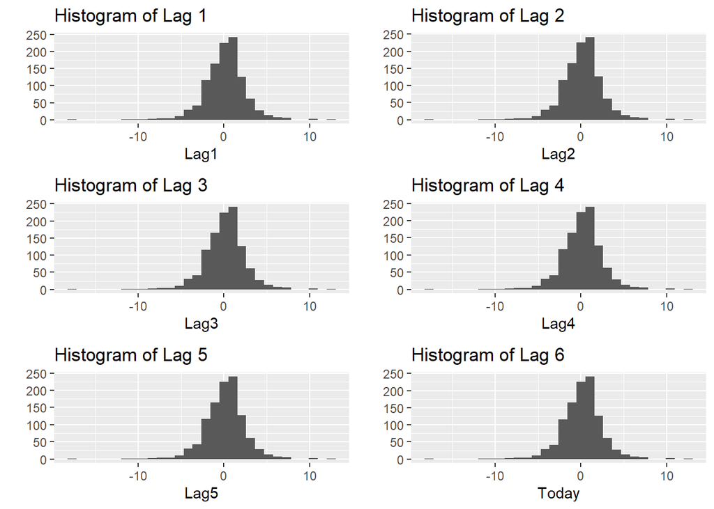

```r
#install.packages("gridExtra")
library(gridExtra)
library(ggplot2)

{
lag1 <- qplot(x = Lag1, data = Weekly, main = "Histogram of Lag 1")
lag2 <- qplot(x = Lag2, data = Weekly, main = "Histogram of Lag 2")
lag3 <- qplot(x = Lag3, data = Weekly, main = "Histogram of Lag 3")
lag4 <- qplot(x = Lag4, data = Weekly, main = "Histogram of Lag 4")
lag5 <- qplot(x = Lag5, data = Weekly, main = "Histogram of Lag 5")
Today <- qplot(x = Today, data = Weekly, main = "Histogram of Lag 6")
grid.arrange(lag1,lag2,lag3,lag4,lag5,Today, nrow = 3, ncol = 2)
}
```

**From the graph above, it can be seen that the distribution resembles a bell-shaped curve, suggesting that all the stock returns is normally distributed, thus support the claim that they have similar distribution.**

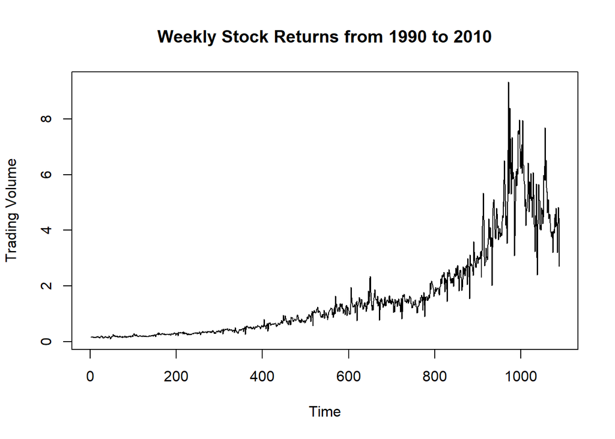

```r
#Plot of Trading Volume over Years
plot(Weekly$Volume, type = "l",main = "Weekly Stock Returns from 1990 to 2010", xlab = "Time", ylab = "Trading Volume")
```

**The plot of Trading Volume over time shows that trading volume increases over time. Towards the end of the dataset, there is a gradual decline in volume and increase in variability of the trading volume, supporting the claim that there is a strong correlation exist between trading volume and year.**

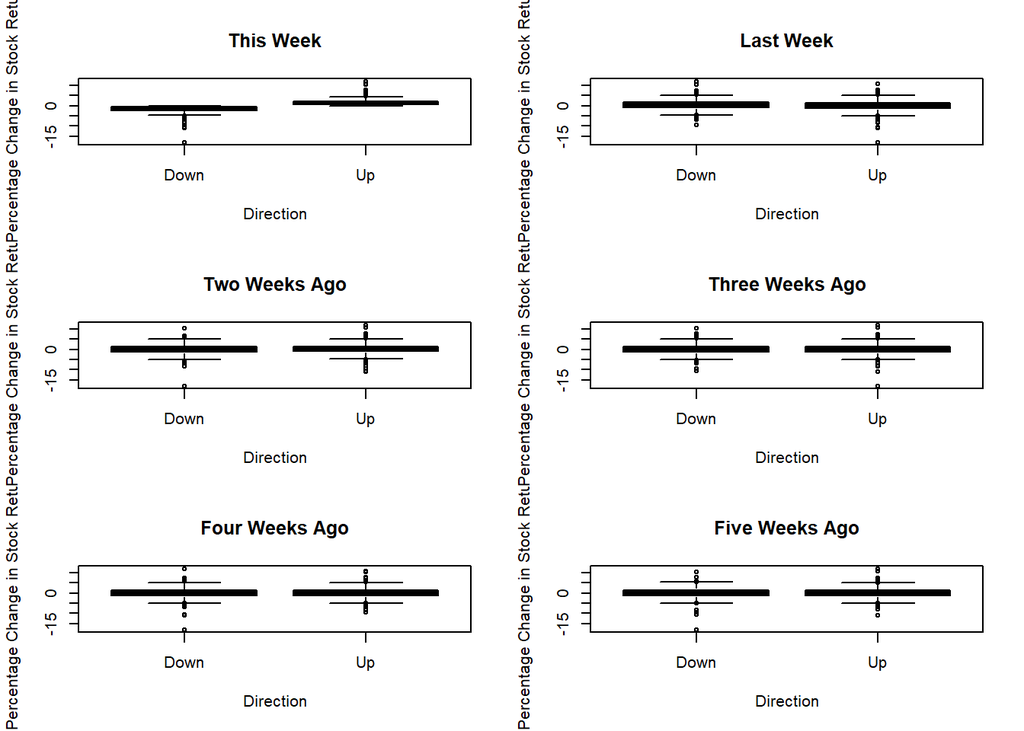

```r
{
par(mfrow = c(3, 2))

#Boxplot Illustrating Relationship between "Direction" and Percentage Change in Stock Return
p1 <- boxplot(Weekly$Today ~ Weekly$Direction, col = c("red","blue"), main = "This Week", xlab = "Direction", ylab = "Percentage Change in Stock Return")

p2 <- boxplot(Weekly$Lag1 ~ Weekly$Direction, col = c("red","blue"), main = "Last Week", xlab = "Direction", ylab = "Percentage Change in Stock Return")

p3 <- boxplot(Weekly$Lag2 ~ Weekly$Direction, col = c("red","blue"), main = "Two Weeks Ago", xlab = "Direction", ylab = "Percentage Change in Stock Return")

p4 <- boxplot(Weekly$Lag3 ~ Weekly$Direction, col = c("red","blue"), main = "Three Weeks Ago", xlab = "Direction", ylab = "Percentage Change in Stock Return")

p5 <- boxplot(Weekly$Lag4 ~ Weekly$Direction, col = c("red","blue"), main = "Four Weeks Ago", xlab = "Direction", ylab = "Percentage Change in Stock Return")

p6 <- boxplot(Weekly$Lag5 ~ Weekly$Direction, col = c("red","blue"), main = "Five Weeks Ago", xlab = "Direction", ylab = "Percentage Change in Stock Return")
}
```

**The second boxplot illustrates the direction of market movement for the current week versus percentage change in returns one week ago. The same thing goes with the third, fourth, fifth and sixth boxplots, which illustrate the direction of market movement for the current week verses the percentage change in stock returns two weeks ago, three weeks ago, fourth weeks ago and fifth weeks ago, respectively.**

2. Fit a logistic regression with `Direction` as the response and different combinations of lag variables plus `Volume` as predictors. Use the period from 1990 to 2008 as your training set and 2009-2010 as your test set. Produce a summary of results.

```r
#Training Set
Weekly_Training <- Weekly[Weekly$Year %in% c(1980:2008),]

#Test Set
Weekly_Test <- Weekly[Weekly$Year %in% c(2009:2010),]
```

```r
#Possible Combinations of Logistic Regression Model
fits <- list()

{
fits$f1 <- glm(Direction ~ Lag1 + Volume, data = Weekly_Training, family = binomial)
fits$f2 <- glm(Direction ~ Lag2 + Volume, data = Weekly_Training, family = binomial)
fits$f3 <- glm(Direction ~ Lag3 + Volume, data = Weekly_Training, family = binomial)
fits$f4 <- glm(Direction ~ Lag4 + Volume, data = Weekly_Training, family = binomial)
fits$f5 <- glm(Direction ~ Lag5 + Volume, data = Weekly_Training, family = binomial)

fits$f6 <- glm(Direction ~ Lag1 + Lag2 + Volume, data = Weekly_Training, family = binomial)
fits$f7 <- glm(Direction ~ Lag1 + Lag3 + Volume, data = Weekly_Training, family = binomial)
fits$f8 <- glm(Direction ~ Lag1 + Lag4 + Volume, data = Weekly_Training, family = binomial)
fits$f9 <- glm(Direction ~ Lag1 + Lag5 + Volume, data = Weekly_Training, family = binomial)

fits$f10 <- glm(Direction ~ Lag2 + Lag3 + Volume, data = Weekly_Training, family = binomial)
fits$f11 <- glm(Direction ~ Lag2 + Lag4 + Volume, data = Weekly_Training, family = binomial)
fits$f12 <- glm(Direction ~ Lag2 + Lag5 + Volume, data = Weekly_Training, family = binomial)

fits$f13 <- glm(Direction ~ Lag3 + Lag4 + Volume, data = Weekly_Training, family = binomial)
fits$f14 <- glm(Direction ~ Lag3 + Lag5 + Volume, data = Weekly_Training, family = binomial)
fits$f15 <- glm(Direction ~ Lag4 + Lag5 + Volume, data = Weekly_Training, family = binomial)

fits$f16 <- glm(Direction ~ Lag1 + Lag2 + Lag3 + Volume, data = Weekly_Training, family = binomial)
fits$f17 <- glm(Direction ~ Lag1 + Lag2 + Lag4 + Volume, data = Weekly_Training, family = binomial)
fits$f18 <- glm(Direction ~ Lag1 + Lag2 + Lag5 + Volume, data = Weekly_Training, family = binomial)

fits$f19 <- glm(Direction ~ Lag1 + Lag3 + Lag4 + Volume, data = Weekly_Training, family = binomial)
fits$f20 <- glm(Direction ~ Lag1 + Lag3 + Lag5 + Volume, data = Weekly_Training, family = binomial)
fits$f21 <- glm(Direction ~ Lag1 + Lag4 + Lag5 + Volume, data = Weekly_Training, family = binomial)

fits$f22 <- glm(Direction ~ Lag2 + Lag3 + Lag4 + Volume, data = Weekly_Training, family = binomial)
fits$f23 <- glm(Direction ~ Lag2 + Lag4 + Lag5 + Volume, data = Weekly_Training, family = binomial)
fits$f24 <- glm(Direction ~ Lag3 + Lag4 + Lag5 + Volume, data = Weekly_Training, family = binomial)

fits$f25 <- glm(Direction ~ Lag1 + Lag2 + Lag3 + + Lag4 + Volume, data = Weekly_Training, family = binomial)
fits$f26 <- glm(Direction ~ Lag1 + Lag2 + Lag3 + + Lag5 + Volume, data = Weekly_Training, family = binomial)
fits$f27 <- glm(Direction ~ Lag2 + Lag3 + Lag4 + + Lag5 + Volume, data = Weekly_Training, family = binomial)

fits$f28 <- glm(Direction ~ Lag1 + Lag2 + Lag3 + Lag4 + Lag5 + Volume, data = Weekly_Training, family = binomial)
}

#Extract AIC from all the Fitted Model and Arrange According to Descending Order
AIC <- do.call(cbind, lapply(fits, function (z) summary(z)$aic))
AIC <- order(AIC, decreasing = "TRUE")
AIC
```

```
##  [1] 24 13 27 14 15  4 22  3 23  5 10 11 19 28 25 12 20 26  2  7  8 21 16 17  9
## [26]  1 18  6
```

**28 models are fitted with different combinations of the “Lag” variables and respective AIC are compared to determine the best model of all the fitted models. Generally, model with lowest AIC is preferred as AIC is the measure of fit which penalizes model for the number of model coefficients. Therefore, we always prefer model with minimum AIC value. By comparison, it is identified that the 6th fitted model has the lowest AIC value, thus it is chosen as the most suitable model for further analysis.**

```
Do any of the predictors appear to be statistically significant in your training set? If so, which ones?
```

```r
#Logistic Regression with the Best Identified Model using Training Set
fit3 <- glm(Direction ~ Lag1 + Lag2 + Volume, data = Weekly_Training, family = binomial)
summary(fit3)
```

```
##
## Call:
## glm(formula = Direction ~ Lag1 + Lag2 + Volume, family = binomial,
##     data = Weekly_Training)
##
## Coefficients:
##             Estimate Std. Error z value Pr(>|z|)
## (Intercept)  0.29792    0.09136   3.261  0.00111 **
## Lag1        -0.05975    0.02917  -2.048  0.04054 *
## Lag2         0.04774    0.02941   1.624  0.10446
## Volume      -0.07093    0.05263  -1.348  0.17777
## ---
## Signif. codes:  0 '***' 0.001 '**' 0.01 '*' 0.05 '.' 0.1 ' ' 1
##
## (Dispersion parameter for binomial family taken to be 1)
##
##     Null deviance: 1354.7  on 984  degrees of freedom
## Residual deviance: 1345.1  on 981  degrees of freedom
## AIC: 1353.1
##
## Number of Fisher Scoring iterations: 4
```

**From the summary, only Lag1 is significant in the training set with p-value = 0.04054 < 0.05. The rest of the regressors are not significant at 5% confidence level.**

3. From your test set, compute the confusion matrix, and calculate accuracy, precision, recall and F1.

```r
#Logistic Regression by Removing Insignificant Regressor(Lag2)
fit4 <- glm(Direction ~ Lag1 + Volume, data = Weekly_Training, family = binomial)
summary(fit4)
```

```
##
## Call:
## glm(formula = Direction ~ Lag1 + Volume, family = binomial, data = Weekly_Training)
##
## Coefficients:
##             Estimate Std. Error z value Pr(>|z|)
## (Intercept)  0.32025    0.09019   3.551 0.000384 ***
## Lag1        -0.06445    0.02903  -2.220 0.026425 *
## Volume      -0.08391    0.05175  -1.621 0.104948
## ---
## Signif. codes:  0 '***' 0.001 '**' 0.01 '*' 0.05 '.' 0.1 ' ' 1
##
## (Dispersion parameter for binomial family taken to be 1)
##
##     Null deviance: 1354.7  on 984  degrees of freedom
## Residual deviance: 1347.8  on 982  degrees of freedom
## AIC: 1353.8
##
## Number of Fisher Scoring iterations: 4
```

**By comparison, after removing the insignificant variable from fit3, it is discovered that the AIC actually increases, which makes it a less reliable model than fit3. Therefore, Lag2 is retained for computation of confusion matrix even though it is not statistically significant as there is a possibility that Lag2 is a confounding variable.**

```r
#Relevant Packages
#install.packages("caret")
library(caret, quietly = TRUE)
library(stats, quietly = TRUE)

#Logistic Regression
fit5 <- glm(Direction ~ Lag1 + Lag2 + Volume, data = Weekly_Training, family = binomial)

#Test the Model by Fitting the Test Set into Fitted Model
fit5_prob = predict(fit5, Weekly_Test, type = "response")
contrasts(Weekly_Test$Direction)
```

```
##      Up
## Down  0
## Up    1
```

```r
#Compute the Predictions and Compare to Actual Results
fit5_predict = rep("Down", length(fit5_prob))
fit5_predict[fit5_prob > 0.5] = "Up"

#Confusion Matrix
CM_log <- confusionMatrix(mode = "prec_recall", data = factor(fit5_predict), reference = Weekly_Test$Direction)
CM_log
```

```
## Confusion Matrix and Statistics
##
##           Reference
## Prediction Down Up
##       Down   27 33
##       Up     16 28
##
##                Accuracy : 0.5288
##                  95% CI : (0.4285, 0.6275)
##     No Information Rate : 0.5865
##     P-Value [Acc > NIR] : 0.90168
##
##                   Kappa : 0.0821
##
##  Mcnemar's Test P-Value : 0.02227
##
##               Precision : 0.4500
##                  Recall : 0.6279
##                      F1 : 0.5243
##              Prevalence : 0.4135
##          Detection Rate : 0.2596
##    Detection Prevalence : 0.5769
##       Balanced Accuracy : 0.5435
##
##        'Positive' Class : Down
##
```

```
Explain what the confusion matrix is telling you about the types of mistakes made by logistic regression, and what can you learn from additional measures of fit like accuracy, precision, recall, and F1.
```

**From the summary of confusion matrix above, define “Down” as Positive and “Up” as Negative.**

**Recall: Recall is the ratio of correctly predicted positive observations to the all observations in actual class. For the weeks that the market actually went “Down”, the model predicts correctly 62.79% of the time, which is considered good as it is greater than 0.5.**

**Precision: Precision is the ratio of correctly predicted positive observations to the total predicted positive observations. High precision relates to low false positive rate. In this case, precision is only 45% therefore it indicates that this model has a relatively high false positive rate.**

**F1 Score is the weighted average of Precision and Recall. Therefore, this score takes both false positives and false negatives into account. In this case, F1 score is 52.43%, roughly equivalent to accuracy. As it is preferable to have F1 closer to 1, this model is considered only moderately good.**

```r
Type1Error = CM_log$table[3]/(CM_log$table[3]+CM_log$table[4])
Type1Error
```

```
## [1] 0.5409836
```

```r
Type2Error = 1 - (CM_log$table[1]/(CM_log$table[1]+CM_log$table[2]))
Type2Error
```

```
## [1] 0.372093
```

4. (Extra credit) Experiment with alternative classification methods.

   Present the results of your experiments reporting method, associated confusion matrix, and measures of fit on the test set like accuracy, precision, recall, and F1.

```r
#Linear Discriminant Analysis
#Required Packages
library(MASS)

#Fit the Model with Linear Discriminant Analysis
fit6 <- lda(Direction ~ Lag1 + Lag2 + Volume, data = Weekly_Training)

#Test the Model by Fitting the Test Set into Fitted Model
fit6_prob = predict(fit6, Weekly_Test, type = "response")
fit6_predict = fit6_prob$class

#Confusion Matrix
CM_LDA <- confusionMatrix(mode = "prec_recall", data = factor(fit6_predict), reference = Weekly_Test$Direction)
CM_LDA
```

```
## Confusion Matrix and Statistics
##
##           Reference
## Prediction Down Up
##       Down   27 33
##       Up     16 28
##
##                Accuracy : 0.5288
##                  95% CI : (0.4285, 0.6275)
##     No Information Rate : 0.5865
##     P-Value [Acc > NIR] : 0.90168
##
##                   Kappa : 0.0821
##
##  Mcnemar's Test P-Value : 0.02227
##
##               Precision : 0.4500
##                  Recall : 0.6279
##                      F1 : 0.5243
##              Prevalence : 0.4135
##          Detection Rate : 0.2596
##    Detection Prevalence : 0.5769
##       Balanced Accuracy : 0.5435
##
##        'Positive' Class : Down
##
```

```r
#Quantitative Descriptive Analysis
#Required Packages
library(MASS)

#Fit the Model with Linear Discriminant Analysis
fit7 <- qda(Direction ~ Lag1 + Lag2 + Volume, data = Weekly_Training)

#Test the Model by Fitting the Test Set into Fitted Model
fit7_prob = predict(fit7, Weekly_Test, type = "response")
fit7_predict = fit7_prob$class

#Confusion Matrix
CM_QDA <- confusionMatrix(mode = "prec_recall", data = factor(fit7_predict), reference = Weekly_Test$Direction)
CM_QDA
```

```
## Confusion Matrix and Statistics
##
##           Reference
## Prediction Down Up
##       Down   31 44
##       Up     12 17
##
##                Accuracy : 0.4615
##                  95% CI : (0.3633, 0.562)
##     No Information Rate : 0.5865
##     P-Value [Acc > NIR] : 0.9962
##
##                   Kappa : -3e-04
##
##  Mcnemar's Test P-Value : 3.435e-05
##
##               Precision : 0.4133
##                  Recall : 0.7209
##                      F1 : 0.5254
##              Prevalence : 0.4135
##          Detection Rate : 0.2981
##    Detection Prevalence : 0.7212
##       Balanced Accuracy : 0.4998
##
##        'Positive' Class : Down
##
```

```r
#K Nearest Neighbour
#Required Packages
library(class, quietly = TRUE)
library(caret, quietly = TRUE)

#Varying K in KNN Model to Decide the Best K
set.seed(1234)
trctrl <- trainControl(method = "repeatedcv", number = 10, repeats =3)
fit8 <- train(Direction ~ Lag1 + Lag2 + Volume, data = Weekly_Training, method = "knn", trControl = trctrl, preProcess = c("center", "scale"), tuneLength = 25)
fit8
```

```
## k-Nearest Neighbors
##
## 985 samples
##   3 predictor
##   2 classes: 'Down', 'Up'
##
## Pre-processing: centered (3), scaled (3)
## Resampling: Cross-Validated (10 fold, repeated 3 times)
## Summary of sample sizes: 887, 887, 886, 886, 886, 887, ...
## Resampling results across tuning parameters:
##
##   k   Accuracy   Kappa
##    5  0.5099500  0.001737494
##    7  0.5123073  0.005677306
##    9  0.5211333  0.020538732
```

[output cut: 25 more lines]

**From the model, it is identified that the accuracy is the highest when k=43. Therefore, k=43 is used for the KNN model below.**

```r
fit8_prob = predict(fit8, Weekly_Test)
CM_KNN <- confusionMatrix(mode = "prec_recall", data = factor(fit8_prob), reference = Weekly_Test$Direction)
CM_KNN
```

```
## Confusion Matrix and Statistics
##
##           Reference
## Prediction Down Up
##       Down   25 26
##       Up     18 35
##
##                Accuracy : 0.5769
##                  95% CI : (0.4761, 0.6732)
##     No Information Rate : 0.5865
##     P-Value [Acc > NIR] : 0.6193
##
##                   Kappa : 0.151
##
##  Mcnemar's Test P-Value : 0.2913
##
##               Precision : 0.4902
##                  Recall : 0.5814
##                      F1 : 0.5319
##              Prevalence : 0.4135
##          Detection Rate : 0.2404
##    Detection Prevalence : 0.4904
##       Balanced Accuracy : 0.5776
##
##        'Positive' Class : Down
##
```

```r
#Bagging
#Required Packages
#install.packages("randomForest")
library(randomForest, quietly = TRUE)
bag <- randomForest(Direction ~ Lag1 + Lag2 + Volume, data = Weekly_Training, mtry = 3)
bag_predict = predict(bag, Weekly_Test, type = "response")

CM_bag <- confusionMatrix(mode = "prec_recall", data = factor(bag_predict), reference = Weekly_Test$Direction)
CM_bag
```

```
## Confusion Matrix and Statistics
##
##           Reference
## Prediction Down Up
##       Down   28 37
##       Up     15 24
##
##                Accuracy : 0.5
##                  95% CI : (0.4003, 0.5997)
##     No Information Rate : 0.5865
##     P-Value [Acc > NIR] : 0.970013
##
##                   Kappa : 0.0415
##
##  Mcnemar's Test P-Value : 0.003589
##
##               Precision : 0.4308
##                  Recall : 0.6512
##                      F1 : 0.5185
##              Prevalence : 0.4135
##          Detection Rate : 0.2692
##    Detection Prevalence : 0.6250
##       Balanced Accuracy : 0.5223
##
##        'Positive' Class : Down
##
```

```r
#Random Forest
library(randomForest, quietly = TRUE)

rf <- randomForest(Direction ~ Lag1 + Lag2 + Volume, data = Weekly_Training, mtry = 1)
rf_predict = predict(rf, Weekly_Test, type = "response")

CM_rf <- confusionMatrix(mode = "prec_recall", data = factor(rf_predict), reference = Weekly_Test$Direction)
CM_rf
```

```
## Confusion Matrix and Statistics
##
##           Reference
## Prediction Down Up
##       Down   30 37
##       Up     13 24
##
##                Accuracy : 0.5192
##                  95% CI : (0.4191, 0.6183)
##     No Information Rate : 0.5865
##     P-Value [Acc > NIR] : 0.931618
##
##                   Kappa : 0.0842
##
##  Mcnemar's Test P-Value : 0.001143
##
##               Precision : 0.4478
##                  Recall : 0.6977
##                      F1 : 0.5455
##              Prevalence : 0.4135
##          Detection Rate : 0.2885
##    Detection Prevalence : 0.6442
##       Balanced Accuracy : 0.5456
##
##        'Positive' Class : Down
##
```

```r
#Comparing Results
library(knitr, quietly = TRUE)

Table <- rbind(CM_log$overall["Accuracy"], CM_LDA$overall["Accuracy"], CM_QDA$overall["Accuracy"], CM_KNN$overall["Accuracy"], CM_bag$overall["Accuracy"], CM_rf$overall["Accuracy"])

rownames(Table) = c("Logistic Regression", "Linear Discriminant Analysis", "Quantitative Discriminant Analysis", "K-Nearest Neighbour", "Bagging", "Random Forest")
colnames(Table) = "Accuracy"

kable(Table)
```

|  | Accuracy |
| --- | --- |
| Logistic Regression | 0.5288462 |
| Linear Discriminant Analysis | 0.5288462 |
| Quantitative Discriminant Analysis | 0.4615385 |
| K-Nearest Neighbour | 0.5769231 |
| Bagging | 0.5000000 |
| Random Forest | 0.5192308 |